# analysis survival cox model and logrank

Zhengkun Ou

2025-11-30

```r
hf <- read.csv("heart_failure_clinical_records_dataset.csv")
str(hf)
```

```
## 'data.frame':    299 obs. of  13 variables:
##  $ age                     : num  75 55 65 50 65 90 75 60 65 80 ...
##  $ anaemia                 : int  0 0 0 1 1 1 1 1 0 1 ...
##  $ creatinine_phosphokinase: int  582 7861 146 111 160 47 246 315 157 123 ...
##  $ diabetes                : int  0 0 0 0 1 0 0 1 0 0 ...
##  $ ejection_fraction       : int  20 38 20 20 20 40 15 60 65 35 ...
##  $ high_blood_pressure     : int  1 0 0 0 0 1 0 0 0 1 ...
##  $ platelets               : num  265000 263358 162000 210000 327000 ...
##  $ serum_creatinine        : num  1.9 1.1 1.3 1.9 2.7 2.1 1.2 1.1 1.5 9.4 ...
##  $ serum_sodium            : int  130 136 129 137 116 132 137 131 138 133 ...
##  $ sex                     : int  1 1 1 1 0 1 1 1 0 1 ...
##  $ smoking                 : int  0 0 1 0 0 1 0 1 0 1 ...
##  $ time                    : int  4 6 7 7 8 8 10 10 10 10 ...
##  $ DEATH_EVENT             : int  1 1 1 1 1 1 1 1 1 1 ...
```

```r
table(hf$DEATH_EVENT)
```

```
##
##   0   1
## 203  96
```

We can see that there are 96 deaths in the dataset and 203 survivals.

```r
summary(hf$time)
```

```
##    Min. 1st Qu.  Median    Mean 3rd Qu.    Max.
##     4.0    73.0   115.0   130.3   203.0   285.0
```

```r
surv_obj <- with(hf, Surv(time = time, event = DEATH_EVENT))
```

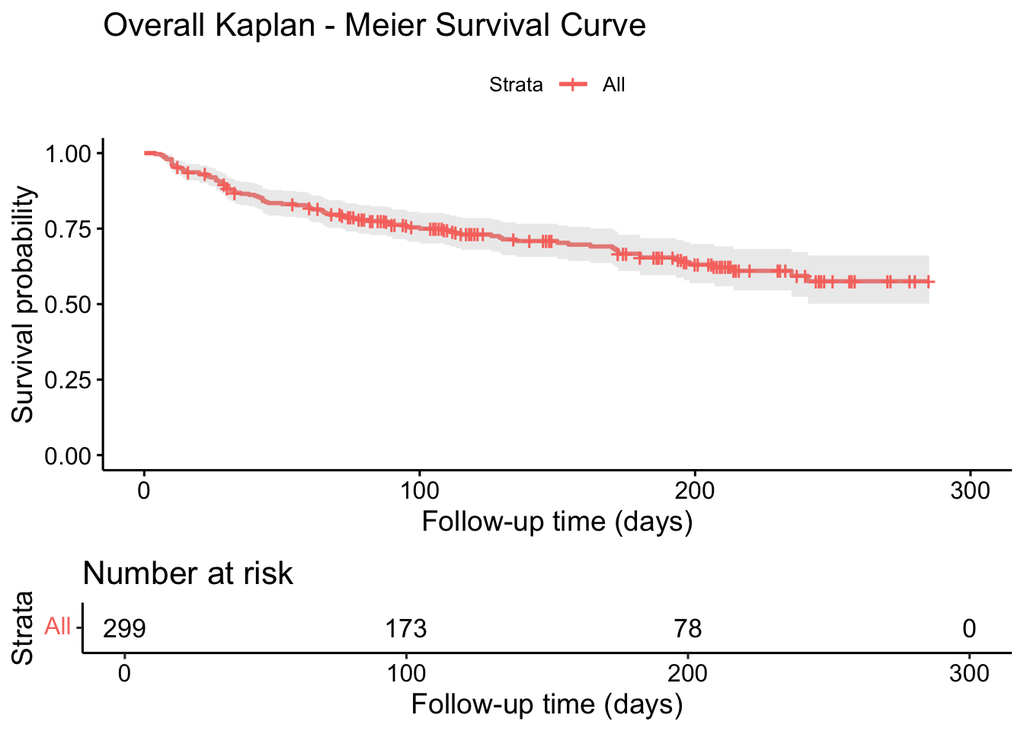

```r
fit_overall <- survfit(surv_obj ~ 1, data = hf)

ggsurvplot(
  fit_overall,
  conf.int = TRUE,
  risk.table = TRUE,
  xlab = "Follow-up time (days)",
  ylab = "Survival probability",
  title = "Overall Kaplan - Meier Survival Curve",
  surv.median.line = "hv"
)
```

KM curves by a categorical covariate

Pick a clinically relevant binary covariate, e.g. high_blood_pressure:

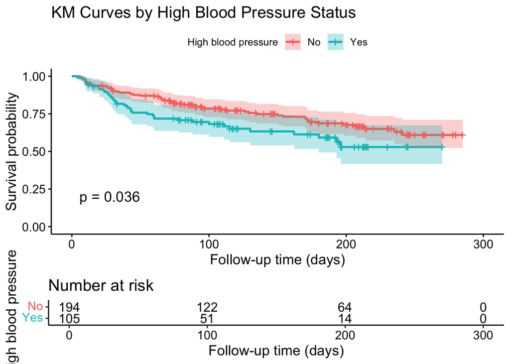

```r
hf$high_bp_factor <- factor(hf$high_blood_pressure, labels = c("No HBP", "HBP"))

fit_bp <- survfit(surv_obj ~ high_bp_factor, data = hf)

ggsurvplot(
  fit_bp,
  data = hf,
  conf.int = TRUE,
  pval = TRUE,          # log-rank p-value by default
  risk.table = TRUE,
  legend.title = "High blood pressure",
  legend.labs = c("No", "Yes"),
  xlab = "Follow-up time (days)",
  ylab = "Survival probability",
  title = "KM Curves by High Blood Pressure Status"
)
```

We can see that the KM curve shows an significant difference in surval probability when we make comparison between patients with high blood pressure and no high blood pressure. We compared survival between patients with and without high blood pressure using a log-rank test, which is appropriate for comparing two Kaplan–Meier curves under approximately proportional hazards. The test indicated a statistically significant difference in survival (p = 0.036).

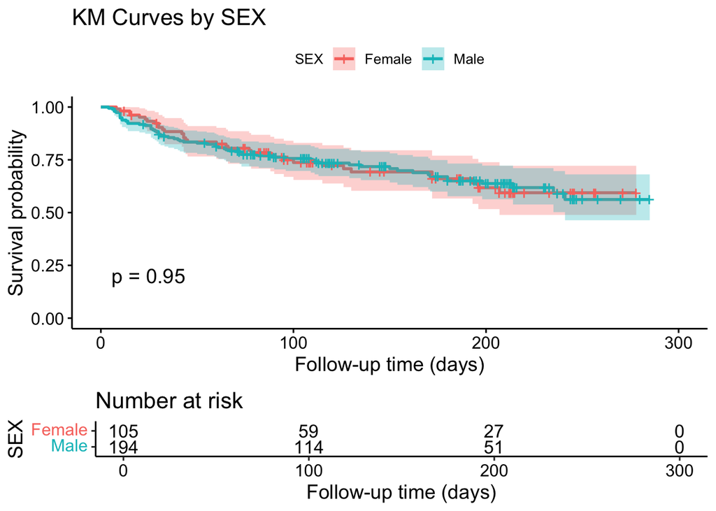

```r
hf$sex_factor <- factor(hf$sex, labels = c("Female", "Male"))
fit_sex <- survfit(surv_obj ~ sex_factor, data = hf)
ggsurvplot(
  fit_sex,
  data = hf,
  conf.int = TRUE,
  pval = TRUE,          # log-rank p-value by default
  risk.table = TRUE,
  legend.title = "SEX",
  legend.labs = c("Female", "Male"),
  xlab = "Follow-up time (days)",
  ylab = "Survival probability",
  title = "KM Curves by SEX"
)
```

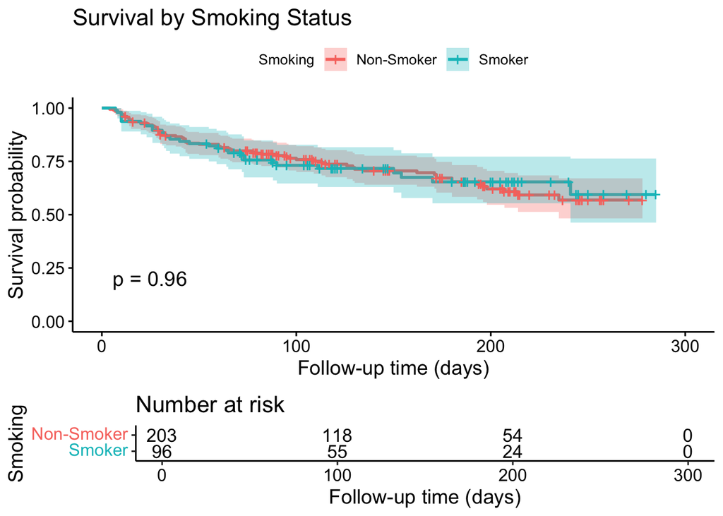

```r
hf$smoking_factor <- factor(hf$smoking, labels = c("Non-Smoker", "Smoker"))
fit_smoking <- survfit(surv_obj ~ smoking_factor, data = hf)

ggsurvplot(
  fit_smoking,
  data = hf,
  conf.int = TRUE,
  risk.table = TRUE,
  pval = TRUE,         # shows log-rank p-value
  xlab = "Follow-up time (days)",
  ylab = "Survival probability",
  title = "Survival by Smoking Status",
  legend.title = "Smoking",
  legend.labs = c("Non-Smoker", "Smoker")
)
```

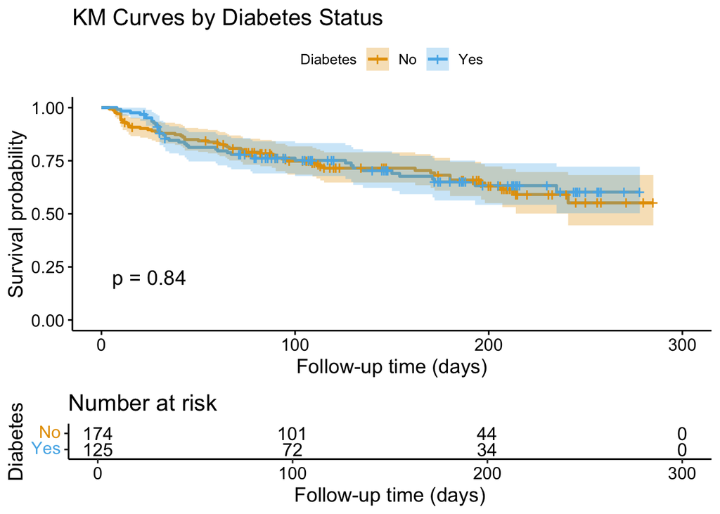

```r
surv_obj <- with(hf, Surv(time, DEATH_EVENT))

hf$diabetes_factor <- factor(hf$diabetes, labels = c("No Diabetes", "Diabetes"))

fit_diabetes <- survfit(surv_obj ~ diabetes_factor, data = hf)

ggsurvplot(
  fit_diabetes,
  data = hf,
  conf.int = TRUE,
  risk.table = TRUE,
  pval = TRUE,                    # log-rank p-value
  xlab = "Follow-up time (days)",
  ylab = "Survival probability",
  title = "KM Curves by Diabetes Status",
  legend.title = "Diabetes",
  legend.labs = c("No", "Yes"),
  palette = c("#E69F00", "#56B4E9")
)
```

Use log-rank test for each binary predictor:

```r
predictors <- c("diabetes", "high_blood_pressure", "smoking",
                "anaemia", "sex")
for (v in predictors) {
  print(survdiff(surv_obj ~ hf[[v]], data = hf))
}
```

```
## Call:
## survdiff(formula = surv_obj ~ hf[[v]], data = hf)
##
##             N Observed Expected (O-E)^2/E (O-E)^2/V
## hf[[v]]=0 174       56       55    0.0172    0.0405
## hf[[v]]=1 125       40       41    0.0231    0.0405
##
##  Chisq= 0  on 1 degrees of freedom, p= 0.8
## Call:
## survdiff(formula = surv_obj ~ hf[[v]], data = hf)
##
##             N Observed Expected (O-E)^2/E (O-E)^2/V
## hf[[v]]=0 194       57     66.4      1.34      4.41
## hf[[v]]=1 105       39     29.6      3.00      4.41
##
##  Chisq= 4.4  on 1 degrees of freedom, p= 0.04
## Call:
## survdiff(formula = surv_obj ~ hf[[v]], data = hf)
##
##             N Observed Expected (O-E)^2/E (O-E)^2/V
## hf[[v]]=0 203       66     65.8   0.00064   0.00204
## hf[[v]]=1  96       30     30.2   0.00139   0.00204
##
##  Chisq= 0  on 1 degrees of freedom, p= 1
## Call:
## survdiff(formula = surv_obj ~ hf[[v]], data = hf)
##
##             N Observed Expected (O-E)^2/E (O-E)^2/V
## hf[[v]]=0 170       50     57.9      1.07      2.73
## hf[[v]]=1 129       46     38.1      1.63      2.73
##
##  Chisq= 2.7  on 1 degrees of freedom, p= 0.1
## Call:
## survdiff(formula = surv_obj ~ hf[[v]], data = hf)
##
##             N Observed Expected (O-E)^2/E (O-E)^2/V
## hf[[v]]=0 105       34     34.3   0.00254   0.00397
## hf[[v]]=1 194       62     61.7   0.00141   0.00397
##
##  Chisq= 0  on 1 degrees of freedom, p= 0.9
```

```r
uni_results <- lapply(predictors, function(v) {
  summary(coxph(surv_obj ~ hf[[v]], data = hf))
})
```

```r
data.frame(
  variable = predictors,
  HR = sapply(uni_results, \(x) exp(x$coef)),
  p = sapply(uni_results, \(x) x$wald["pvalue"])
)
```

```
##              variable      HR.1     HR.2      HR.3     HR.4     HR.5          p
## 1            diabetes 0.9590214 1.546430 0.9904595 1.401254 1.013655 0.84002836
## 2 high_blood_pressure 2.6091419 4.694681 2.6924713 4.060287 2.755655 0.03735024
## 3             smoking 1.2303328 1.232936 1.2464508 1.227503 1.237930 0.96529115
## 4             anaemia 0.8172116 8.019812 0.9574184 5.185361 1.065606 0.09979680
## 5                 sex 2.3164327 1.038057 2.6255520 1.104946 2.583988 0.94933378
```

```r
# Peto–Peto / Prentice, approx via rho = 1
pp_test <- survdiff(surv_obj ~ high_bp_factor, data = hf, rho = 1)
pp_test
```

```
## Call:
## survdiff(formula = surv_obj ~ high_bp_factor, data = hf, rho = 1)
##
##                         N Observed Expected (O-E)^2/E (O-E)^2/V
## high_bp_factor=No HBP 194     46.6     54.8      1.25      4.71
## high_bp_factor=HBP    105     33.3     25.1      2.72      4.71
##
##  Chisq= 4.7  on 1 degrees of freedom, p= 0.03
```

```r
pp_chisq <- pp_test$chisq
pp_p <- pchisq(pp_chisq, df = length(pp_test$n) - 1, lower.tail = FALSE)
pp_p
```

```
## [1] 0.03004151
```

The Peto–Peto / Prentice test also indicates a significant difference in survival between patients with and without high blood pressure (p = 0.030).

Next, we will fit a Cox proportional hazards model to assess the effect of multiple covariates on survival.

```r
cox_multi <- coxph(
  surv_obj ~ age + sex + ejection_fraction +
    serum_creatinine + high_blood_pressure + diabetes + smoking,
  data = hf
)
summary(cox_multi)
```

```
## Call:
## coxph(formula = surv_obj ~ age + sex + ejection_fraction + serum_creatinine +
##     high_blood_pressure + diabetes + smoking, data = hf)
##
##   n= 299, number of events= 96
##
##                          coef exp(coef)  se(coef)      z Pr(>|z|)
## age                  0.046130  1.047211  0.009319  4.950 7.43e-07 ***
## sex                 -0.133981  0.874606  0.243868 -0.549   0.5827
## ejection_fraction   -0.050223  0.951017  0.010178 -4.934 8.04e-07 ***
## serum_creatinine     0.357357  1.429545  0.067673  5.281 1.29e-07 ***
## high_blood_pressure  0.449465  1.567473  0.213100  2.109   0.0349 *
## diabetes             0.173265  1.189181  0.217661  0.796   0.4260
## smoking              0.060161  1.062008  0.248380  0.242   0.8086
## ---
## Signif. codes:  0 '***' 0.001 '**' 0.01 '*' 0.05 '.' 0.1 ' ' 1
##
##                     exp(coef) exp(-coef) lower .95 upper .95
## age                    1.0472     0.9549    1.0283    1.0665
## sex                    0.8746     1.1434    0.5423    1.4106
## ejection_fraction      0.9510     1.0515    0.9322    0.9702
## serum_creatinine       1.4295     0.6995    1.2520    1.6323
## high_blood_pressure    1.5675     0.6380    1.0323    2.3801
## diabetes               1.1892     0.8409    0.7762    1.8219
## smoking                1.0620     0.9416    0.6527    1.7280
##
## Concordance= 0.73  (se = 0.029 )
## Likelihood ratio test= 72.29  on 7 df,   p=5e-13
## Wald test            = 78.52  on 7 df,   p=3e-14
## Score (logrank) test = 78.59  on 7 df,   p=3e-14
```

From the published study Reference:

Chicco, D., Jurman, G. Machine learning can predict survival of patients with heart failure from serum creatinine and ejection fraction alone. BMC Med Inform Decis Mak 20, 16 (2020).

the main important predictors are: Age

Ejection fraction

Serum creatinine

High blood pressure

Diabetes

Smoking

Sex

Model comparison:

```r
cox_simple <- coxph(surv_obj ~ age + ejection_fraction, data = hf)

anova(cox_simple, cox_multi, test = "LRT")
```

```
## Analysis of Deviance Table
##  Cox model: response is  surv_obj
##  Model 1: ~ age + ejection_fraction
##  Model 2: ~ age + sex + ejection_fraction + serum_creatinine + high_blood_pressure + diabetes + smoking
##    loglik  Chisq Df Pr(>|Chi|)
## 1 -485.06
## 2 -473.06 23.988  5  0.0002183 ***
## ---
## Signif. codes:  0 '***' 0.001 '**' 0.01 '*' 0.05 '.' 0.1 ' ' 1
```

```r
extractAIC(cox_simple)
```

```
## [1]   2.0000 974.1119
```

```r
extractAIC(cox_multi)
```

```
## [1]   7.0000 960.1244
```

The likelihood ratio test comparing the simple and multiple Cox models indicates that the multiple Cox model provides a significantly better fit to the data (p < 0.001). Additionally, the AIC values suggest that the multiple Cox model has a lower AIC (better model fit) compared to the simple model.

```r
car::vif(cox_multi)
```

```
##                 age                 sex   ejection_fraction    serum_creatinine
##            1.064034            1.300296            1.050861            1.058792
## high_blood_pressure            diabetes             smoking
##            1.022696            1.101651            1.265182
```

The variance inflation factors (VIFs) for all covariates in the multiple Cox model are below 5, indicating that multicolinearity is not a concern in this model.

Present adjusted survival curves:

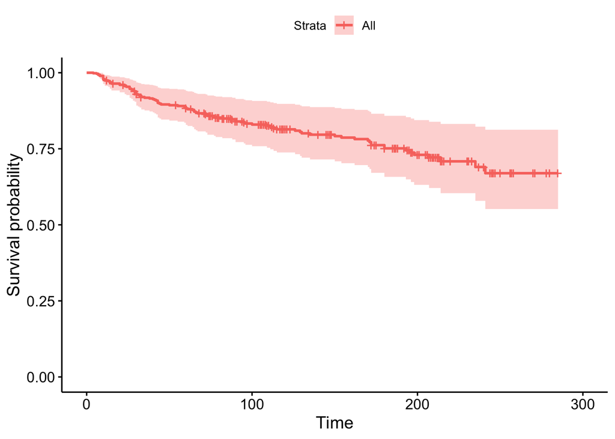

```r
fit_adj <- survfit(cox_multi)
ggsurvplot(fit_adj, data = hf)
```